# Creando paletas de colores y modificando temas

13-12-2021

## Primero carguemos los paquetes que usaremos en este tutorial

```r
library(tidyverse)

library(palmerpenguins)

library(paletteer)
```

## Ejemplos de gráficos estándar - 1

Creemos dos gráficos *por defecto* para modificarlos luego.

```r
barras1 <- ggplot(penguins, aes(y = island, fill = species)) +
  geom_bar() +
  labs(title = "Pingüinos en archipiélago de Palmer",
       subtitle = "Número de pinguinos en cada isla")
```

## Ejemplos de gráficos estándar - 2

Y ahora generaremos un gráfico de puntos, donde en el eje **“x”** irá la variable bill_lenght_mm y en el eje **“y”** irá la variable bill_depth_mm y asignando un color distinto por especie, el que quedará guardado en el objeto *puntos1*

```r
puntos1 <- ggplot(penguins, aes(x = bill_length_mm, y = bill_depth_mm,
                                color = species)) +
  geom_point() +
  labs(title = "Pingüinos en archipiélago de Palmer",
       subtitle = "Dimensiones del pico de diversas especies")
```

## Ejemplos de gráficos estándar - 3

Para ver como quedaron los gráficos utilizaremos la opción print(), la que desplegará en pantalla los gráficos generados

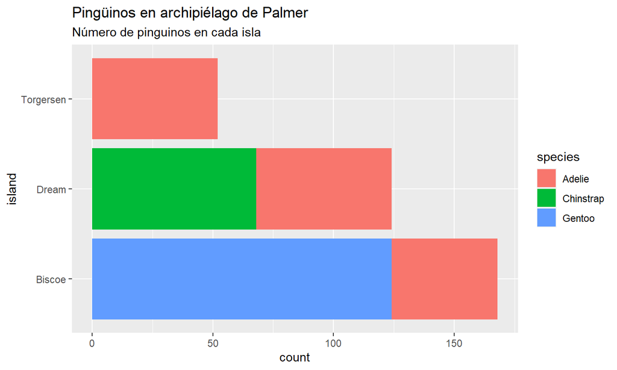

```r
print(barras1)
```

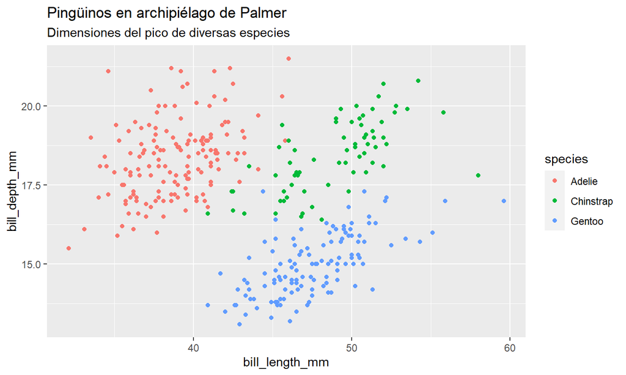

```r
print(puntos1)
```

## Paletas de colores!

[figure not shown]

## Creemos paletas de colores

Con el paquete paletteer podemos acceder a un variado sets de **paletas de colores** para poder modificar los colores de los gráficos ya generados, por ejemplo veremos qué colores nos ofrece la paleta X20 del paquete beyonce.

Al ejecutar la siguente línea, en la consola se despliegan los códigos alfanuméricos de los colores de esta paleta

```r
paletteer_d("beyonce::X20")
```

```
## <colors>
## #1B0204FF #4E0C0DFF #881618FF #B01515FF #C47F4EFF #773924FF
```

Una manera de utilizar un set de colores específicos es asignándolos a un vector, para esto copiaremos los códigos de los colores de la paleta que vimos en el paso anterior al vector col_d_1

```r
col_d_1 <- c("#1B0204FF", "#4E0C0DFF", "#881618FF", "#B01515FF",
             "#C47F4EFF", "#773924FF")
```

## Aplicando paletas de colores - 1

Para aplicar una paleta de colores a un gráfico mostraremos dos maneras:

1.- Utilizar la función scale_fill_manual() para gráficos de barras o la función scale_color_manual() para gráficos de puntos, luego a nuestros gráficos ya generados les aplicamos la paleta guardada en nuestro vector col_d_1 a través de la opción (values = ).

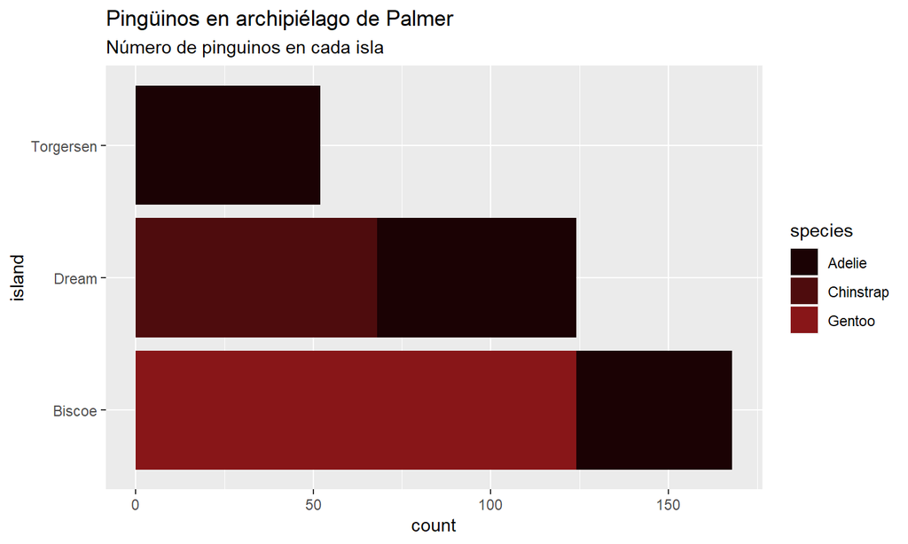

```r
barras1 +
  scale_fill_manual(values = col_d_1)
```

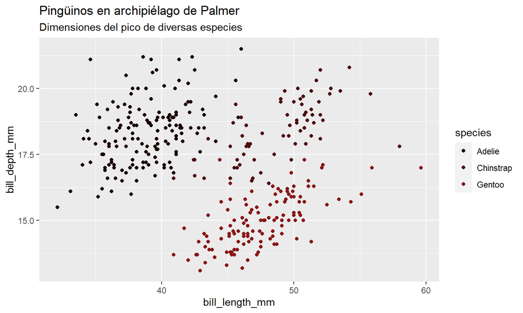

```r
puntos1 +
  scale_color_manual(values = col_d_1)
```

## Aplicando paletas de colores - 2

2.- Otra manera de utilizar una paleta creada por nosotros, es asignar a un objeto lo que hace la función scale_fill_manual() para un gráfico de barras, o la función scale_color_manual() para un gráfico de puntos, y aplicar la paleta guardada en nuestro vector col_d_1 a través de la opción (values = ). Para aplicar la paleta a los gráficos de base basta con agregar el operador **“+”** a los objetos que contienen el *gráfico* y *la paleta de colores*

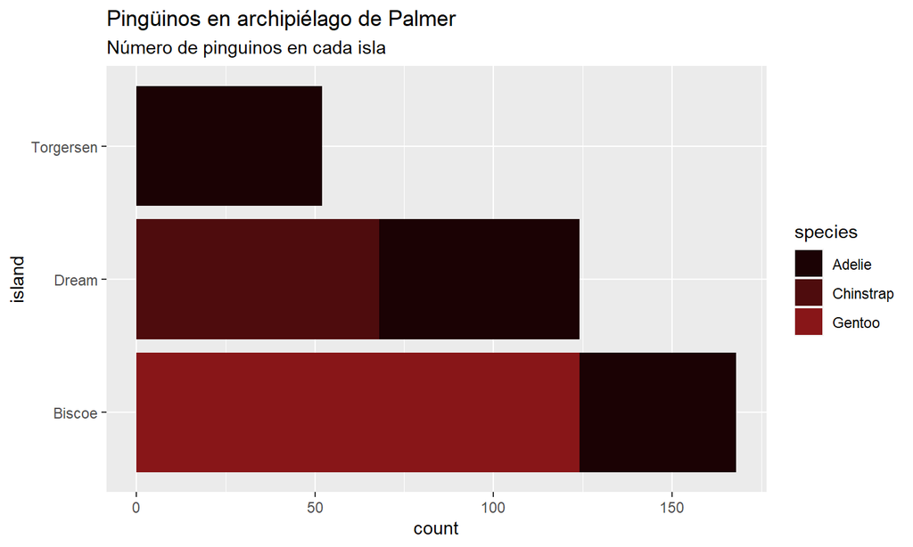

```r
mi_fill_1 <-
  scale_fill_manual(values = col_d_1)
barras1 + mi_fill_1
```

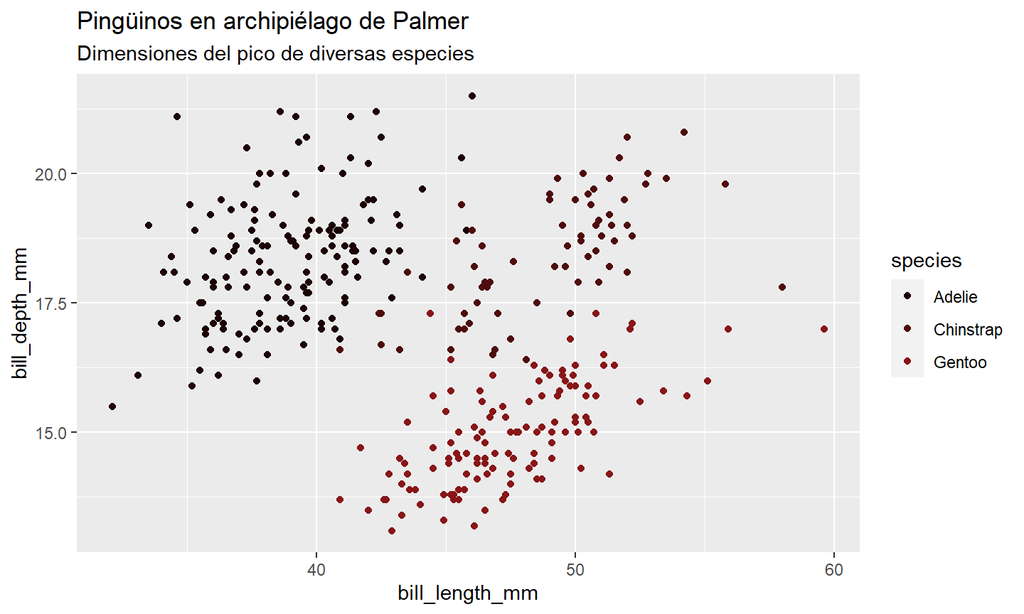

```r
mi_color_1 <-
  scale_color_manual(values = col_d_1)
puntos1 + mi_color_1
```

## Aplicando paletas de colores - 3

Ideas para buscar paletas discretas aquí https://emilhvitfeldt.github.io/r-color-palettes/discrete.html

Otra manera de asignar paletas de colores es usando las funciones scale_fill_paletteer_d() o scale_color_paletteer_d() para barras1 y puntos1, te dejamos un par de ejemplos según sea apropiado (1 para barras1 y 1 para puntos1)

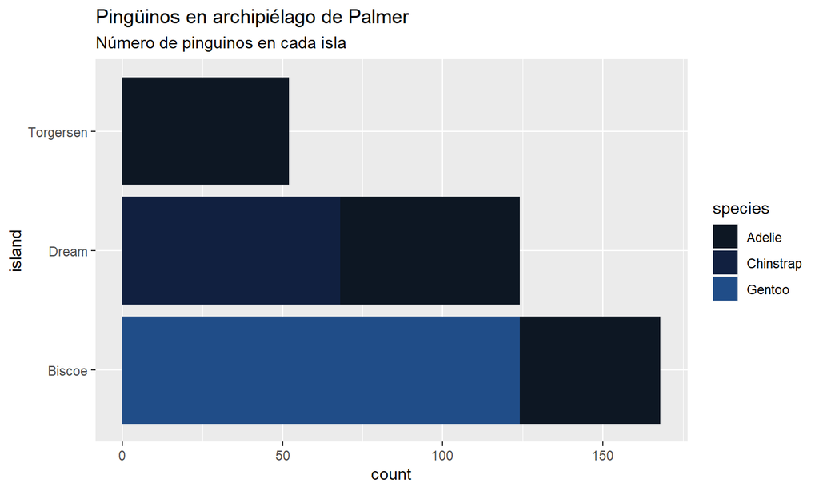

```r
barras1 +
  scale_fill_paletteer_d("beyonce::X7")
```

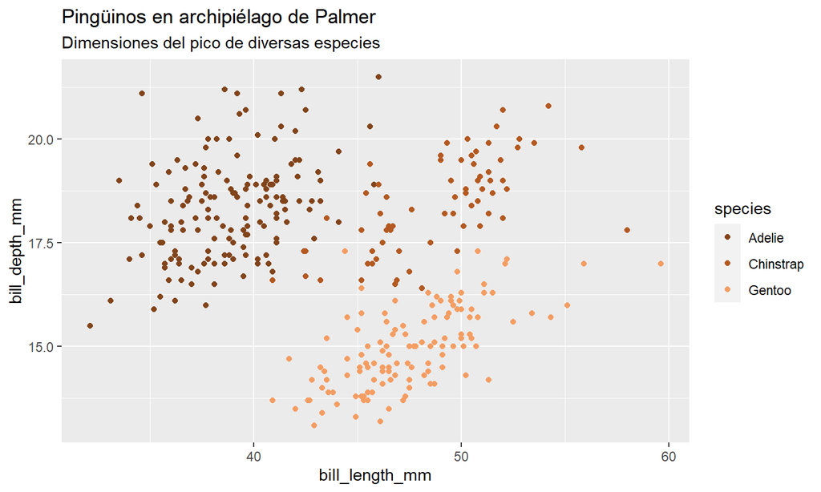

```r
puntos1 +
  scale_color_paletteer_d("beyonce::X28")
```

## Modificando temas!

[figure not shown]

## Modificando Títulos y/o Subtítulos - 1

R nos ayuda a utilizar los distintos paquetes que hay a disposición de los usuarios para modificar gráficos, muestra de esto en https://ggplot2.tidyverse.org/articles/articles/faq-customising.html

Aquí podemos encontrar opciones de cómo modificar el tamaño de la letra de los títulos y subtítulos, por ejemplo a nuestros gráficos les dejaremos más grande el tamaño de la letra del título que la del subtítulo utilizando la función theme() y aplicaremos la paleta de colores *mi_fill_1* y *mi_color_1* según el tipo de gráfico

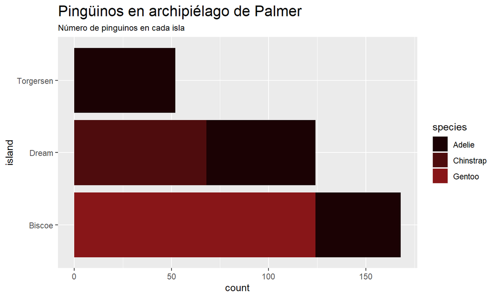

```r
barras1 + theme(
  plot.title =
    element_text(size = 16),
  plot.subtitle =
    element_text(size = 9)
) + mi_fill_1
```

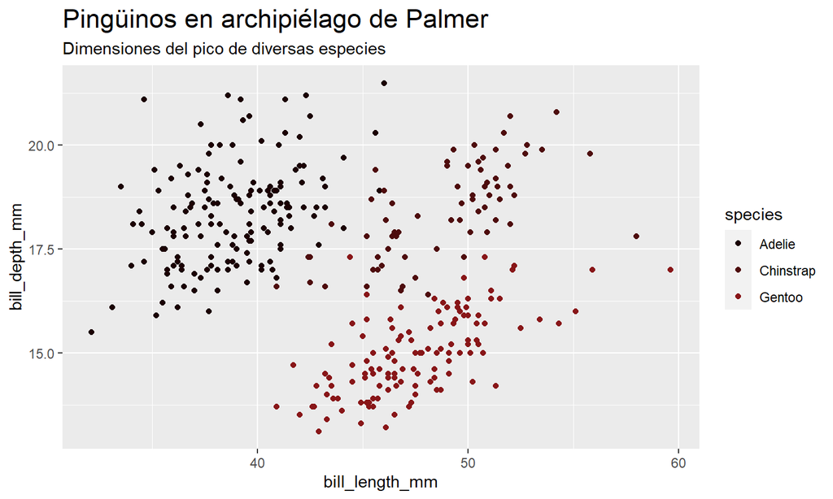

```r
puntos1 + theme(
  plot.title =
    element_text(size = 17),
  plot.subtitle =
    element_text(size = 11)
) + mi_color_1
```

## Modificando Títulos y/o Subtítulos - 2

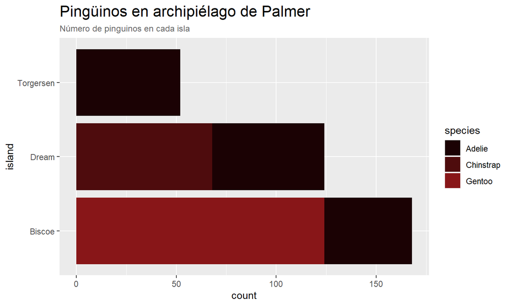

```r
barras1 + theme(
  plot.title =
    element_text(size = 16),
  plot.subtitle =
    element_text(size = 9,
        color = "grey40")
) + mi_fill_1
```

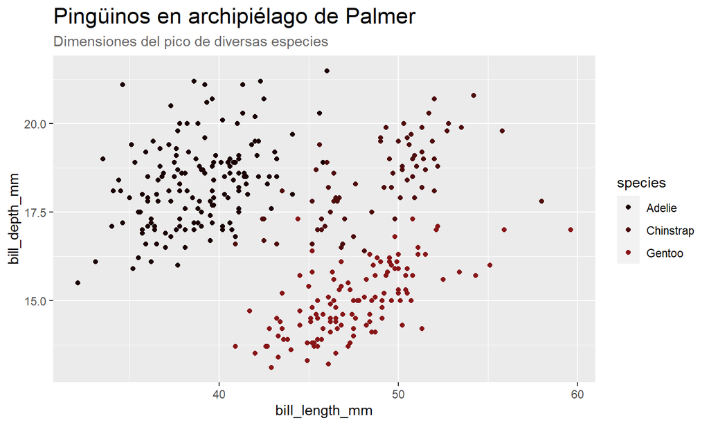

```r
puntos1 + theme(
  plot.title =
    element_text(size = 17),
  plot.subtitle =
    element_text(size = 11,
       color = "grey40")
) + mi_color_1
```

## Modificando background del interior del gráfico y eliminando las grillas mayores y menores

En https://ggplot2-book.org/polishing.html podemos encontrar opciones para modificar el background y grillas mayores y menores en un gráfico, te dejamos un ejemplo de cómo hacerlo.

```r
ejemplo <- puntos1 + theme(
plot.title = element_text(size = 17,
              color ='grey20'),
plot.subtitle = element_text(size = 11,
              color = "grey40"),
panel.grid.major = element_blank(),
panel.grid.minor = element_blank(),
panel.background = element_blank()
) + mi_color_1
```

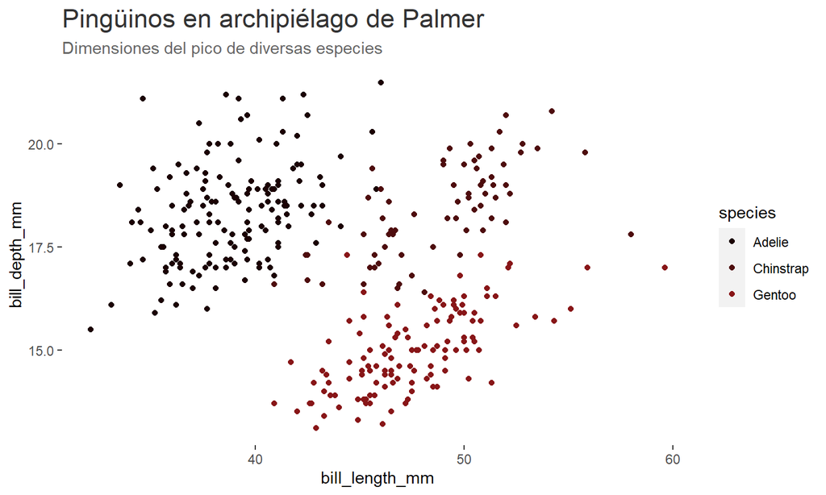

```r
print(ejemplo)
```

## Guardando las preferencias de gráficos

Una manera simple y útil es guardar el código que hemos escrito en los ejemplos anteriores en un objeto con el nombre que nos acomode, por ejemplo **“mis_cambios_de_tema”** y luego aplicar esos cambios a cualquier gráfico con el operador **“+”**

```r
mis_cambios_de_tema <- theme(
  plot.title = element_text(size = 17,color ='grey20'),
  plot.subtitle = element_text(size = 11, color = "grey40"),
  panel.grid.major = element_blank(),
  panel.grid.minor = element_blank(),
  panel.background = element_blank()
)
```

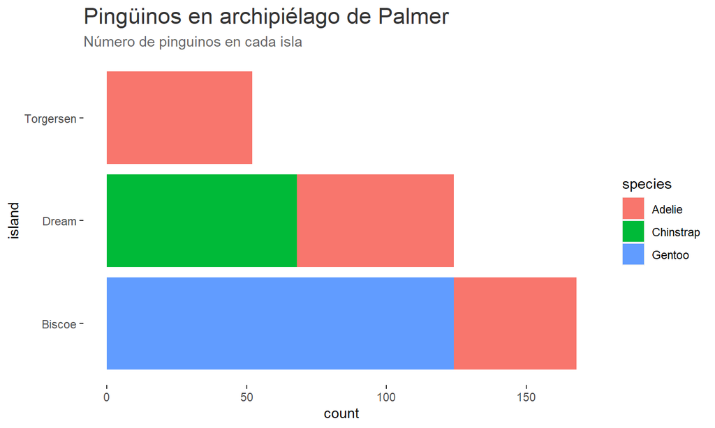

```r
barras1 +
  mis_cambios_de_tema
```

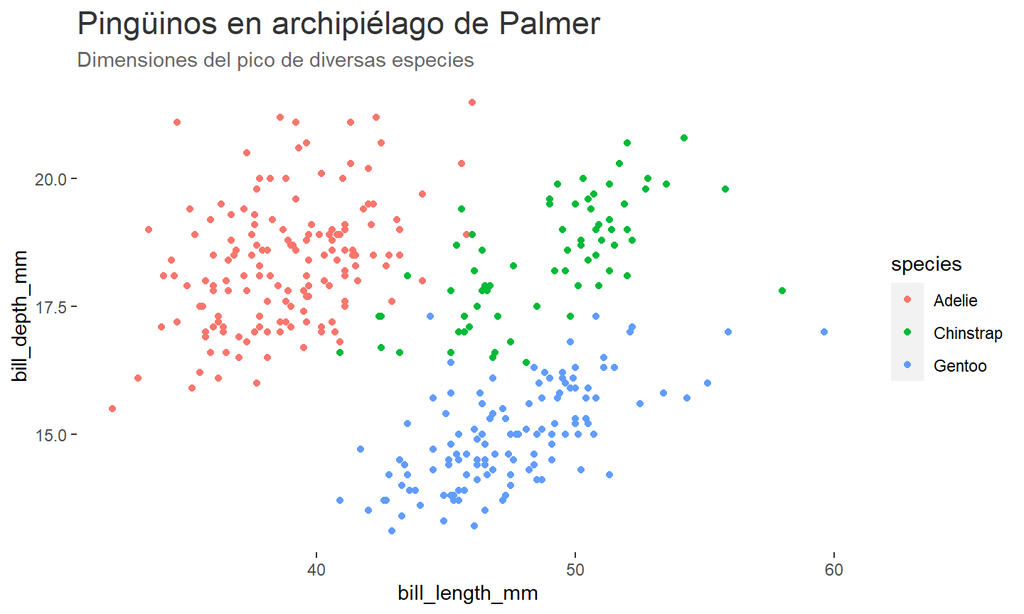

```r
puntos1 +
  mis_cambios_de_tema
```

Y ahora podemos aplicar de una sola vez los cambios de *“temas”* y *“paletas de colores”* a cualquier gráfico con el operador **“+”**

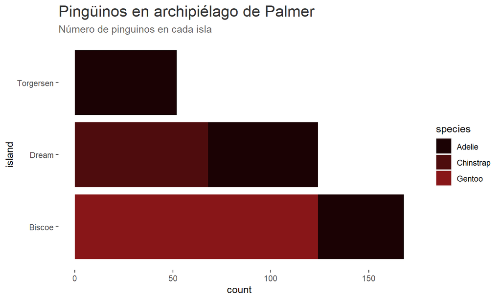

```r
barras1 +
  mis_cambios_de_tema +
  mi_fill_1
```

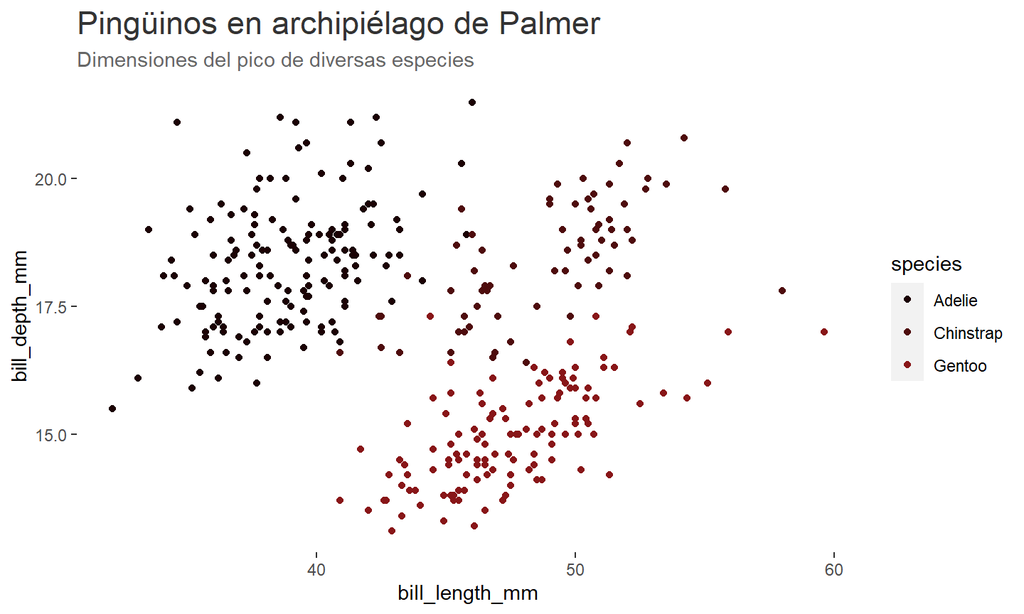

```r
puntos1 +
  mis_cambios_de_tema +
  mi_color_1
```

## Guardando las preferencias de gráficos en un archivo

Otra opción bastante utilizada es guardar las preferencias de gráficos en un archivo .R, para lo cual se deben dejar las paletas de colores de preferencia y los temas seleccionados según la elección de cada usuario.

En el *script* a continuación se dejan los cambios de formato de gráficos que cada usaurio estime y se debe guardar con un nombre y la extensión .R, para este ejemplo lo llamaremos *“cambios_graficosv2.R”*

```r
library(tidyverse)

col_d_1 <- c("#1B0204FF", "#4E0C0DFF", "#881618FF", "#B01515FF",
             "#C47F4EFF", "#773924FF")

mi_fill_1 <- scale_fill_manual(values = col_d_1)
mi_color_1 <- scale_color_manual(values = col_d_1)


mis_cambios_de_tema <- theme(
  plot.title = element_text(size = 17,color ='grey20'),
  plot.subtitle = element_text(size = 11, color = "grey40"),
  panel.grid.major = element_blank(),
  panel.grid.minor = element_blank(),
  panel.background = element_blank()
)
```

## Llamando el archivo con la base de formato de gráficos

Y ahora podemos llamar este archivo *“cambios_graficosv2.R”* con el formato que hemos establecido para ser usado en cualquier script de .R

- source(“cambios_graficosv2.R”)

- library(palmerpenguins)

- library(paletteer)